# São Jorge, el Tepoz de Goaias

Black bird

6/11/2017

[figure not shown]

## Generalidades

São Jorge es un pueblo con otro tipo de aire, a tan solo 35 km de Alto de Paraiso, es un lugar completamente diferente. Dos calles de tierra (principal A, principal B y para de contar), una decena de posadas, unos cuantos restaurantes y dos bares, es tierra colonizada por esta especie fácilmente criticable que no hace nada por los lugares que visitan, los tan aclamados “nuevos hippies”. Esto ha hecho que SJ se convierta en un pueblo que finge ser hippie pero que en realidad esconde una infraestructura bastante decente, ¿no parece que hablo de Tepoz? (sólo faltan los Argentinos).

Posadas con aire acondicionado, tele a cable, internet, hidromasaje en el cuarto, súper desayuno incluido, Wii-Fii; campamentos limpios con colchones inflables para rentar, camas al aire libre, baños más limpios que los del Sangrons, música en vivo, hamacas y etiqueta negra en el bar, restaurantes con jazz en vivo, platos de hasta $400 (pesos) son el tipo de infraestructura que me hace pensar que este lugar es mucho más que la imagen que da.

Finalmente, la ciudad es perfecta para ejercer el “hipismo” confortablemente, se llega por una carretera de tierra (unos 14 kilómetros), las calles también son de tierra, es tierra de nadie, estás “en contacto” con la naturaleza y todo eso con comodidad plena de campings limpios y cómodos, restaurantes “por kilo” muy accesibles y demás infraestructura de la que ya hablé.

Pero bueno, no dejen que mi amargura interna los desanime, vayan a São Jorge porque dentro de todo es un pueblito genial, se come bien, se hospeda muy bien, las personas (aunque menos que Cavalcante) son muy interesantes pero sobre todo estar fuera de la ciudad, ¡ir a las cascadas y demás vale mucho la pena!

**Nota al lector:** Los nombres marcados con un (*) son bautizos nuestros, por lo que ir a São Jorge y buscarlos por el nombre no es una buena idea, mejor usen las referencias ;).

## Hospedaje

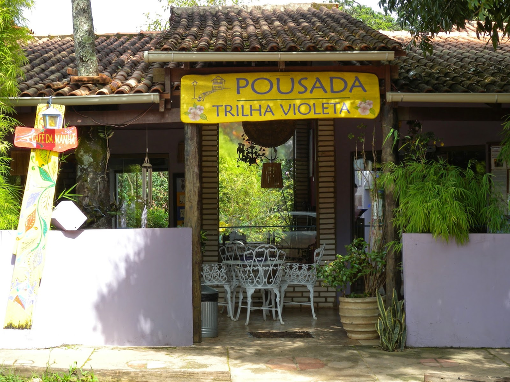

A cheirosa*, debo de admitir, después de 5 días en posadas bastantes… “económicas” el cuerpo necesita algo más así que cuando llegamos a São Jorge decidimos ir a buscar la posada ideal y después de entrar en unas 10 de nuestra “categoría” decidimos por último entrar en la “Trilha Violeta Pousada”y nos enamoramos de su cuarto limpiecito, perfumado y arregladito. La posada cuenta con alrededor de 14 cuartos, ventilador, área de hamaca, masajes desayuno incluido, una terraza muy simpática e internet, el precio es muy accesible y queda un poco retirada del ruido nocturno del pueblo, de las mejores opciones que encontramos en la zona.

*Dirección. Calle principal B, pasando el “Bar Frontal” frente al árbol a la mitad del camino de tierra (punto)* Tel. (62) 3455 - 1088 y (61) 9985 - 6544 Página y mail. www.trilhavioleta.com.br y trilhavioleta@trilhavioleta.com.br

- *É pau, é pedra é o fim do caminho… são as Aguas de Marzo fechando o verão…* Casi al final de la calle principal B (o el principio porque en realidad ¿dónde empieza dónde termina, cuál es el sentido? chan chan chaaaaaan) del lado derecho tenemos una posada que, como hija de la ciudad, aparenta mucho menos de lo que en realidad es. una fachada simple, entrada aún más simple y un dueño muy amable, la posada es enorme tiene varias habitaciones para 1, 2 3 personas, con aire acondicionado o sin aire, hamacas, desayuno completo incluido, internet y TV (en la recepción) y no sólo eso, esta maravilla de lugar tiene alberca, baño japonés (whatever that means) y lo más padre de todo sauna de leña; en realidad parece un horno de pizza para gente, una maravilla para relajar en la noche después de un día agitado. Aún más alejada del bullicio de la ciudad es una excelente opción de hospedaje en São Jorge.

*Dirección. Pasando el árbol a la mitad de la calle, cuatro rocas después, donde el viento empieza a dar la vuelta, del lado derecho.* Tel. (61) 9962 - 2082 Página. www.chapadadosveadeiros.com.br

- *Posada de no se cuánto*, el único edificio del pueblo, esta posada quiebra un poco con el visual del lugar, una edificación color crema de dos pisos paralela a la calle B entre el charco mayor y la subida al monte. No tiene mucho más que cuartos con ventilador o AC, en un precio alto R180-R230, respectivamente. El desayuno incluido es en un desayunado local que, a pesar de bueno, dependiendo de la suerte te toca hasta su madre y lo padre de la posada es que todos los cuartos tienen una vista súper padre de las montañas y es la más cerca al parque dos Veadeiros. No tengo contactos de esta más que l nombre del dude, “Seu Artur” creo.
- *POSADA NO SE QUE*, probablemente la dirección más directa que podré dar, en la calle B, dirección al Parque Nacional da Chapada dos Veadeiros antes del charco mayor, después de la curva, subiendo el monte, del lado derecho van a ver dos posadas, son las dos más lujosas del lugar (de las que yo vi). La primera cuesta R180 por habitación doble, tienen aire acondicionado, TV en el cuarto, internet rápido, alberca, bar en la alberca, desayuno incluido y se ve muy muy Nice, creo que para quién está buscando/acostumbrado al lujo, esto es lo más adecuado.

**Nota:** al lado hay otra, la fulanita de tal, esta posada me pareció un exceso, no llegué a ver los cuartos pero lo único que cambia es que tienen hidromasaje (si, en cada cuarto hay hidromasaje) lo cual, a la mitad de Alaska o algún lugar así dice “óooooorale, va, la compro” pero en este lugar paradisíaco donde tienes albercas naturales de hidromasaje de cascada, ¿para qué diablos va alguien gastar R$400 (aprox $200 dlrs) en una habitación? Para su consideración…

- *Campamento do Parque,* si lo que buscas es austeridad verdadera, acampar y demás, entonces este es el lugar. El hospedaje más cercano al Parque da Chapada, corre una vibra muy buena. Llegamos de noche, el cuidador no estaba y entramos a ver, una fogata prendida, tiendas de campaña bajo árboles, una buena explanada para crear tu espacio, una cocina simple pero deficiente y unos baños que parecían bastante decentes. No atendió un perdido a toda madre, el techo de este lugar es negro lleno de puntitos blancos, caraaaaaaaaaaaaaaaaaalho. R$25
- *Campamento fresa,* al inicio del Camino A hay una pizzería donde hay unos Aliens, enfrente está el Campamento TAL. Un concepto bastante interesante y padre que engloba la esencia del “nuevo hippie”, me maldigo en este momento por no haber tomado fotos pero la idea es la siguiente. Un bar al lado de un área designada a presentaciones teatrales y música, todas las noches (o casi todas) hay alguien tocando de 8pm a 12pm, el que quiera puede tocar, sólo tiene que hablar con Bruno, el dueño (o con su “mamá” que está muy presente en nombre pero no en persona) al lado de esto hay una parte muy grande como de “lunge” colchones, sillones, salas, camas en tapancos, iluminado muy tensamente con luces moradas, verdes y rojas, hacen el lugar ideal para romancear en la noche y para ser festín de moscos. Una vez atravesada esta parte encuentras la cocina y los baños, bastante bien arreglados y grandes y en el fondo el área de camping. Este lugar tiene algunas cosas interesantes que vale la pena resaltar:
- No tienes que llevar tu tienda pues ellos te rentan una con todo y colchón infalible y sábanas.
- Si haces alguna gracia (música, teatro, yoga, etc.) puedes ofrecer clases o show y hospedarte gratis o con descuento, tienes que hablar con Bruno, o su mamá, es un buen esquema si no tienes mucho dinero.
- Se supone que la música termina 12:00 en punto, pero siempre queda gente, no es el lugar para ir si buscas tranquilidad.

## Alimentación

- *Desayuno, en hotel.* Casi todos los lugares son con desayuno en el hotel o en este “desayunador” que al parecer se atasca en algún momento de la mañana.
- *Comida del bar de jazz**. En la calle principal B. casi llegando al charco hay un restaurante bastante simpático con grupo en vivo, pizza a la leña y una mesa de billar. Un buen lugar para comer y bastante agradable. La música es un volado, es decir depende del grupo que toque en ese momento porque creo que no hay filtro.
- *Restaurante Delicias**. La calle principal A y B tienen a su largo dos calles que las unen, la segunda calle en la esquina hay una casita blanca que es un restaurante. Quien atiende y cocina es la dueña y se come maravillosamente. Un lugar muy simpático en donde, con tiempo, puedes pedir “Galinha caipira” algo que no probé pero seguramente es maravillosa. Cosa buena, se puede pagar con tarjeta y en verdad que se come bien.
- *Risotto R50*.* “Eeeeequiiiiiis en la vida weeee” El risotto, la gran cosa del restaurante no es nada del otro mundo, es muy caro y no es tan bueno. El lugar si es muy padre, cómodo y tiene una terraza que presume una tarde muy buena. Tal vez la comida “normal” este mejor de sabor. Cómo llegar: en el árbol parado a la mitad de la Calle B hay una calle transversal, caminas unos 30 metros hasta llegar al campo, cuando el camino se convierte en pasto doblas a la derecha y cuando encuentres unos conejos que se creen perros (te vas a dar cuenta) llegaste, a la derecha, un predio de dos pisos con terraza.
- *Pizza del marciano.* Frente al camping “nice” la comida es X pero vayan en domingo y van a ver lo animado que se pone el caraoque, una experiencia única en la vida!
- *Buffet de pastas.* La cola es grande así que llega temprano, la verdad solo vale la pena si estás corto en cash porque por R$15 puedes tener dos dosis grandes de pasta. ¡Apréndete tu salsa favorita porque tú eliges que ponerle a la pasta!
- **Bar Frontal.** Como todo lugar, hay un frontal y São Jorge no es la excepción. Frente a la Posada Trilha Violeta hay una “tiendita” con un “espacio” y unas “bancas” simplemente el mejor lugar para sentarse a tomar una chela bien fría y planear los siguientes días.
- *Bar Luiz Gonzaga*… Mandacaru quando flora na seca é o sinal que a chuva chega no sertão, toda menina que enjoa da boneca e sinal que o amore já chegou no coração…. Lo bautizamos así porque en la noche que fuimos tocó toda la noche el mismo CD de éxitos del gran Luiz Gonzaga y 3 días después, cuando nos íbamos, seguia tocando el mismo CD… El bar es simple, unas mesas unas chelas y un dueño simpático, no se necesita más en este país, una vista al pueblo (punto)… Mandacaru quando flora na seca é o sinal que a chuva chega no sertão, toda menina que enjoa da boneca é sinal que o amore já chegou no coração….

Me parece que con eso termino con São Jorge, las generalidades y su ciudad. Habría que comentar que no hay gasolinera, hay un pequeño súper en donde consigues todo (hasta vino decente) hay posadas con mucha menos infraestructura por como 50R pero no vale la pena comentar y creo que tampoco hospedarse.

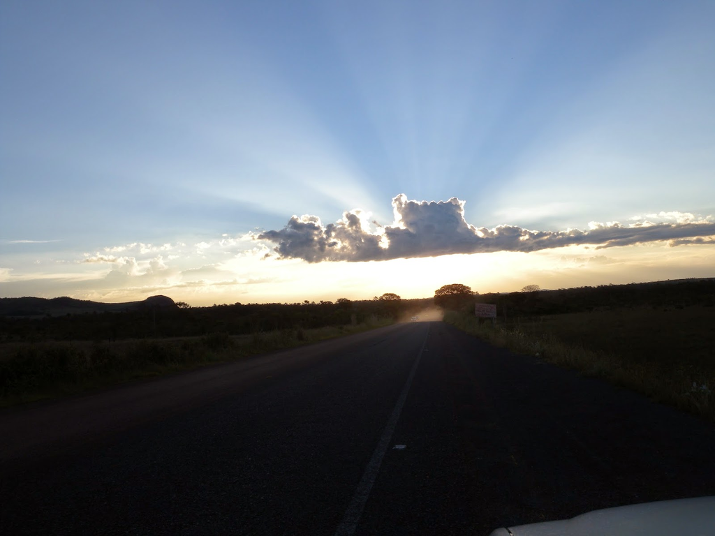